# Deep Probabilistic Causal Modelling in Pyro

**Logan Graham**

Machine Learning Research Group University of Oxford

20 February 2019

# What is Pyro?

Pyro is a probabilistic programming language (PPL) intended to make it easy to integrate **deep learning** with **probabilistic methods**.

You:

1. Write a graphical model
2. Define your estimators (deep / not-deep) as part of the model
3. Choose inference method (MCMC / VI)
- It's built **on top of PyTorch**, which makes gradient-based Bayesian deep learning easy
- Additionally, it appears that its inference primitives make writing your own inference procedures straightforward

## In comparison

1. vs. **PyMC3** and **STAN**: same MCMC techniques + variational inference + deep model integration + write intuitively in Python
2. vs. **Edward**: dynamic computational graph creation + models are Python functions + intuitive

# Building Deep Probabilistic Models in Pyro

1. Say we're going to use some arbitrary nonlinear estimator:

```python
import torch
from torch import nn

class MLP(nn.Module):
    def __init__(self, dim, h):
        # define network params
        super(MLP, self).__init__()
        self.lin1 = nn.Linear(dim, h)
        self.lin2 = nn.Linear(h, 1)

    def forward(self, x):
        # define forward pass
        h1 = nn.functional.relu(self.lin1(x))
        return self.lin2(h1)

net = MLP(dim + 1, h=5)
```

We're going to turn it into a probabilistic model:

```python
def make_net_probabilistic(net, p, h):
    w1_prior = dist.Normal(torch.zeros(p), torch.ones(p)).to_event(1)
    b1_prior = dist.Normal(torch.zeros(1), torch.ones(1)).to_event(1)
    w2_prior = dist.Normal(torch.zeros(h), torch.ones(h)).to_event(1)
    b2_prior = dist.Normal(torch.zeros(1), torch.ones(1)).to_event(1)

    priors = {'lin1.weight': w1_prior, 'lin1.bias': b1_prior,
              'lin2.weight': w2_prior, 'lin2.bias': b2_prior}

    lifted_net = pyro.random_module("module", net, priors)
    return lifted_net()
```

Then build your model with `pyro.sample()` and `pyro.param()` statements:

```python
import pyro
import pyro.distributions as dist

def model(X, y, k=3, h=5):
    n, p = X.shape
    z_dist = pyro.sample("z_dist", dist.Dirichlet(torch.ones(k)))
    locs = pyro.param("locs", torch.ones(k))
    sigma = pyro.param("sigma", dist.LogNormal(1, 1).sample())
    net = MLP()
    net = make_net_probabilistic(net, p, h)
    with pyro.plate("data", n):
        z = pyro.sample("z", dist.Categorical(z_dist))
        z_embed = pyro.sample("z_embed", dist.Normal(locs[z], 1))
        d = torch.cat((z, X))
        y = pyro.sample("y", dist.Normal(net(d), obs=y))
```

Then define a guide, or a variational distribution:

```python
from torch.distributions.constraints import simplex, positive

def guide(X, y, k=3, h=5):
    """
    The guide model representing a chosen variational distribution.
    All non-observed sample statements have to be included with the same name.
    """
    n, p = X.shape
    z_dist = pyro.sample("z_dist", dist.Dirichlet(torch.ones(k)), constraint=simplex)
    locs = pyro.param("locs", torch.ones(k))
    sigma = pyro.param("sigma", dist.LogNormal(1, 1).sample(), constraint=positive)
    with pyro.plate("data", n)
        z = pyro.sample("z", dist.Categorical(z_dist))
        z_embed = pyro.sample("z_embed", dist.Normal(locs[z], 1))
```

Then run inference:

```python
optim = pyro.optim.SGD({'lr':1e-4, 'momentum':1e-1})
loss = pyro.infer.Trace_ELBO()
svi = pyro.infer.SVI(model, guide, optim, loss)

n_steps = 5000
for _ in range(n_steps):
    loss = svi.step(X, y)
```

## In summary:

1. Define model
2. Define estimators
3. Define a variational distribution if using VI (MCMC methods built in as well)
4. Perform inference

# Causal Inference with Pyro

1. We're interested in the **treatment effect** given some **intervention**, $do(X=x)$:

$$TE = P(Y | do(X=x))$$

e.g.: *What's the effect on a patient's heart rate if I give them drug $x$? otherwise:* $P(Heart\ rate\ |\ give\ drug\ x)$

An **intervention** fixes the value of a variable, holding all other nodes equal.

### Usually, we we'd consider the conditional distribution:

$TE \approx P(Y | X=x)$

[figure not shown]

We define the model...

```python
def model():
    Z = pyro.sample("Z", dist.Bernoulli(0.5))
    X = pyro.sample("X", dist.Bernoulli(Z))
    return pyro.sample("Y", dist.Bernoulli(X + Z))
```

And now we see if the conditional model and the interventional model have the same distributions.

```python
def conditioned_model(model, x, n=1):
    return pyro.condition(model, data={"X": x})()

def intervened_model(model, x):
    return pyro.do(model, data={'X': x})()  # Pearl's do-operator

x_value = 0.
```

...and we see that in the presence of confounding, the **interventional distribution** is different from the **conditional distribution**.

[figure not shown]

```python
import matplotlib.pyplot as plt
%matplotlib inline

plt.style.use("seaborn-white")
plt.hist(conditional_distribution, alpha=0.5, label='Conditional $P(Y | X=0))$')
plt.hist(intervened_distribution, alpha=0.5, label='Interventional $P(Y | do(X=0)))$')
plt.legend()
plt.xlabel("X")
plt.ylabel("Frequency")
```

...thus $P(Y|X) \neq P(Y|do(X))$, so fitting a function naively $Y = f(X)$ will be **confounded** or **biased**.

Instead, we need someway to recover the unconfounded function.

Let's build a bayesian model in Pyro leveraging deep models based on the assumption that some $f: X \rightarrow Y$ is complex, and then perform an intervention to recover the interventional distribution.

## Debiasing with Instrumental Variables

[figure not shown]

An *instrumental variable* $\textbf{Z}$ helps us exploit randomness in treatment to estimate the true treatment effect of $X$ on $Y$. $Z$ is a parent variable of our treatment variable that satisfies 3 criteria:

1. **Relevance:** $X \not\!\perp\!\!\!\perp Z$
2. **The Exclusion Restriction:** that is, $Z$ affects $Y$ only through the path $Z \rightarrow X \rightarrow Y$, which implies $Z \perp\!\!\!\perp Y | X$.
3. **Moment Restriction / Unconfoundedness:** $Z \perp\!\!\!\perp (Y - f(X; \theta_{z}) | X$

In essence, $Z$ provides some randomness of treatment assignment $X$ and we wish to model that randomness "pass-through" to $Y$.

*Example: random doctor assignment, treatment number, system outage checks, random service group, random diagnostic model, location proximity changes, rainfall*

# Standard IV

First, we generate some data where $X = (Z\oplus U)\beta$ and $Y = (X\oplus U) \delta$

```python
n = 1000

def generate_data(n):
    with pyro.plate("data", n):
        Z = pyro.sample("Z", dist.Normal(0, 1.25))
        U = pyro.sample("U", dist.Uniform(-2.5, 2.5))
        X = pyro.sample("X", dist.Normal(1*U + 4*Z, torch.tensor([0.001])))
        Y = pyro.sample("Y", dist.Normal(U + 2*X, torch.tensor([0.001])))
    return torch.cat((Z.reshape(-1, 1), U.reshape(-1, 1), X.reshape(-1, 1), Y.reshape(-1, 1)), 1)

data = generate_data(n)
Z, U, X, Y = data.split(1, dim=1)
```

Standard 2-stage least squares is an interpretation of instrumental variables which assumes $X$ is a linear function of $Z$ and $Y$ is a linear function of $X$, and proceeds as follows:

$$ X \approx Z\beta_{Z} $$$$ \hat{\beta_{Z}} = (Z^{T}Z)^{-1}Z^{T}X $$$$ \hat{X} = Z\hat{\beta_{Z}} $$

and that

$$ Y \approx \hat{X}\beta_{\hat{X}} $$$$ \beta_{\hat{X}} = (\hat{X}^{T}\hat{X})^{-1}\hat{X}^{T}Y $$

```python
def B_IV(Z, X, Y):
    mult = np.matmul(Z.numpy().T, X.numpy())
    Z_inv = np.linalg.inv(mult)
    return np.matmul(np.matmul(Z_inv, Z.numpy().T), Y.numpy())

iv_result = B_IV(Z, X, Y).flatten()[0]
print("Estimated causal effect from linear 2SLS (should be ~2): {}".format(iv_result))
```

```
Estimated causal effect from linear 2SLS (should be ~2): 1.9889867305755615
```

When all relationships are linear, it's straightforward to recover the true treatment effect. However, what if relationships ($X | Z$ and $Y | do(X)$) are not linear?

# X | Z is Nonlinear

First, we generate some data where X | Z is not linear.

```python
n = 1000

def generate_data(n):
    with pyro.plate("data", n):
        Z = pyro.sample("Z", dist.Normal(-2, 2))
        U = pyro.sample("U", dist.Normal(-1.5, 1.5))
        X = pyro.sample("X", dist.Normal(0.05*U**2 + 0.005*Z**3, torch.tensor([0.01])))
        Y = pyro.sample("Y", dist.Normal(U + 2*X, torch.tensor([0.01])))
    return torch.cat((Z.reshape(-1, 1), U.reshape(-1, 1), X.reshape(-1, 1), Y.reshape(-1, 1)), 1)

data = generate_data(n)
Z, U, X, Y = data.split(1, dim=1)
```

```
Text(0,0.5,'X')
```

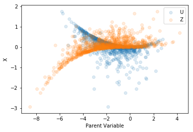

```python
plt.scatter(U, X, alpha=0.15, label="U")
plt.scatter(Z, X, alpha=0.15, label="Z")
plt.legend()
plt.xlabel("Parent Variable")
plt.ylabel("X")
```

```
Text(0,0.5,'Y')
```

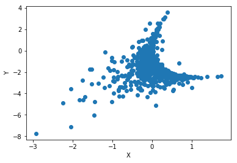

```python
plt.scatter(X, Y)
plt.xlabel('X')
plt.ylabel("Y")
```

This is what we see. On first glance, the relationship between $X$ and $Y$ appears highly positive. Even if we linearly approximated this function, it looks like it will be far greater than the slope of 2 that we know to be the true treatment effect. We are going to show to exploit instrumental variables to recover this relationship.

```python
iv_result = B_IV(Z, X, Y).flatten()[0]
print("Estimated causal effect from linear 2SLS (should be ~2): {}".format(iv_result))
```

```
Estimated causal effect from linear 2SLS (should be ~2): 9.124682426452637
```

Our estimate is heavily biased because X | Z is highly nonlinear (see below) but we are imposing a linear modeling constraint. We'll show how to recover the true effect with a nonlinear, flexible treatment model.

Therefore, we need to model this conditional nonlinearity -- i.e. model $Z | X$ with some appropriate nonlinear probabilistic estimator.

# Nonlinear instrumental variables model

Hartford et al. (2016) extend nonparametric Instrumental Variables to the deep learning case so that we can use arbitrary nonlinear function approximators to capture nonlinearities.

In the standard two-stage scenarios, they show that we can recover the true treatment effect across the space of $X$ if we:

1. Estimate a first stage model of $P(X | Z)$. This is important that we recover a probabilistic estimate of X as we are going to sample from this posterior.
2. Perform second stage:

$$\underset{\theta}{\arg\max} \ |D|^{-1}\Sigma_{i}\biggl(y_{i} - \int h_{\theta}(X)\hat{P}_{\phi}(X | Z)\biggr)^{2}$$

This second stage, as we'll see, can also use an arbitrary nonlinear $h_{\theta}$, so long as we draw from the **conditional treatment distribution** $\hat{P}_{\phi}(X | Z)$.

## 1. Build the first stage model of:

$$\hat{P}_{\phi}(X | Z)$$

For which we're going to use a Gaussian Process (but could easily be any other probabilistic model, such as a mixture density network):

```python
kernel = gp.kernels.RBF(X.shape[-1],
                        variance=torch.tensor(1.),
                        lengthscale=torch.tensor(1.))

model = gp.models.GPRegression(X=X,
                              y=Y.flatten(),
                              kernel=kernel,
                              jitter=1e-4)
```

```python
class TreatmentModel(object):
    """
    Class for a general first stage model.
    Any model class can be used, so long as it samples from a posterior P(X_hat | Z, M).
    The model prediction must output a mean and covariance for every Z,
    and sampling from this model must sample from this resulting normal distribution.
    """
    def __init__(self):
        self.hyperopt = True
        self.trained = False
        self.optimizer = torch.optim.Adam
        self.optim_params = {}
        self.n_steps = 1000
        self.verbose = True
        self.print_loss = 50
        self.loss_fn = pyro.infer.Trace_ELBO().differentiable_loss

    def _get_model(self, X, y):
        """
        Returns a probabilistic model.
        This can be any probabilistic model, but in this implementation
        returns a Gaussian Process.
        """
        assert y.dim() == 1, "Error: can only handle unidimensional outputs."
        if y.shape[-1] == 1:
            y = y.flatten()
        kernel = gp.kernels.RBF(X.shape[-1],
                                variance=torch.tensor(1.),
                                lengthscale=torch.tensor(1.))
        return gp.models.GPRegression(X=X,
                                      y=y,
                                      kernel=kernel,
                                      jitter=1e-4)

    def train(self, Z, X, guide=None):
        """
        Optimize the model using variational inference. Can also
        be optimized with MCMC methods if desired.
        """
        self.pred_dim = X.shape[-1]
        m = self._get_model(Z, X)
        self.trained == True
        pyro.clear_param_store()
        if self.hyperopt:
            if self.verbose:
                print("Beginning hyperparameter optimization.")
            optimizer = self.optimizer(m.parameters(), **self.optim_params)
            self.losses = []
            for step in range(self.n_steps):
                optimizer.zero_grad()
                if guide is None:
                    guide = m.guide
                loss = self.loss_fn(m.model, guide)
                loss.backward()
                optimizer.step()
                self.losses.append(loss.item())
                if self.print_loss is not False and self.verbose:
                    if step % self.print_loss == 0:
                        print("Step {}: {}".format(step, loss))
            self.model = m
            self.guide = guide
        else:
            self.model = m
            self.guide = m.guide
        self.trained = True

    def predict(self, Z):
        """
        A predict function that outputs pointwise means and covariances.
        """
        assert self.trained, "Error: train your model first with the `.train(...)` method."
        return self.model(Z)

    def sample(self, Z, n=1):
        """
        Sample from P(X_hat | M, Z) where M has been trained on {Z, X}.
        """
        assert self.trained, "Error: train your model first with the `.train(...)` method."
        if Z.shape[0] == 1:
            Z = Z.reshape(-1, 1)
        mu, cov = self.predict(Z)
        K = cov.diag()
        return dist.MultivariateNormal(mu, K).sample((n,)).flatten()

    def sample_supervised(self, Z, Y, n=1):
        """
        Samples from P(X_hat | M, Z) and returns vector with corresponding Y vector.
        """
        samples = self.sample(Z, n)
        return torch.cat((samples.reshape(-1, 1),
                          Y.repeat(n).reshape(-1, 1)),
                         dim=1)
```

## 2nd Stage

Because the second stage is linear, we're going to use a linear MLP to show we can use a gradient descent-based method of learning the treatment effect.

```python
class MLP(torch.nn.Module):
    def __init__(self, dim):
        # define network params
        super(MLP, self).__init__()
        self.dim = dim
        self.lin = torch.nn.Linear(dim, 1)

    def forward(self, x):
        return self.lin(x.reshape(-1, self.dim))

def prob_net_linear(dim, name):
    neural_net = MLP(dim)
    w_prior = dist.Normal(torch.zeros(1, dim), torch.ones(1, dim)).to_event(1)
    b_prior = dist.Normal(0, 1)#.to_event(1)
    priors = {'lin.weight': w_prior, 'lin.bias': b_prior}
    lifted_net = pyro.random_module(name, neural_net, priors)
    return lifted_net()
```

## Put it together in a model

### Train Final Treatment Model

First, we'll estimate X | Z using a flexible nonlinear model and confirm that we can use it to recover the true treatment effect.

```python
## train treatment model first
tm = TreatmentModel()
tm.hyperopt = True
tm.optim_params = {"lr": 1e-3}
tm.n_steps = 100
tm.train(Z.flatten(), X.flatten())
```

```
Beginning hyperparameter optimization.
Step 0: 990.184326171875
Step 50: 967.0571899414062
```

```
Text(0,0.5,'X')
```

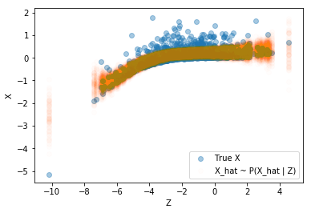

```python
X_hat = tm.sample(Z.flatten(), n=100)
plt.scatter(Z.numpy(), X.numpy(), alpha=0.4, label='True X')
plt.scatter(Z.squeeze(-1).repeat(100).numpy(), X_hat.numpy(), alpha=0.01, label='X_hat ~ P(X_hat | Z)')
plt.legend()
plt.xlabel('Z')
plt.ylabel('X')
```

We can see that we tend to predict X (treatment) well, save for noise information provided by U and non-reduceable noise.

First, we show that we can recover the true treatment effect in this way:

```python
gp_samples = tm.sample_supervised(Z.flatten(), Y.flatten(), 20)
x_hat, Y_hat = gp_samples[:, 0], gp_samples[:, 1]
concat = torch.cat((torch.tensor(np.ones_like(x_hat).reshape(-1, 1)),
                    x_hat.reshape(-1, 1)), 1)
np.linalg.lstsq(concat, Y_hat)[0][-1]
```

```
1.7380142
```

Great, we can still (approximately) recover the true effect when we use a nonlinear treatment model -- at least far better than previously.

### Put into one model

Now we combine the treatment and the estimation model in one simple fully probabilistic program, and train the estimation model using variational inference.

```python
def model(tm, Z, Y, n_samples):
    h = prob_net_linear(1, 'h')  # our nonlinear model
    mu, cov = tm.predict(Z)
    samples = dist.MultivariateNormal(mu, torch.diag(cov))
    with pyro.plate("X_samples", n_samples):
        X_hat = pyro.sample('X_hat', samples)
    y_mu = h(X_hat).squeeze(-1)
    y_pred = pyro.sample("y_pred",
                         dist.Normal(y_mu, 0.1),
                         obs=Y.squeeze(-1).repeat(n_samples))
    return y_pred, h

blocked_model = poutine.block(model, hide=['X_hat', 'X_samples'])
```

```python
pyro.clear_param_store()
guide = pyro.contrib.autoguide.AutoDiagonalNormal(blocked_model)
loss = pyro.infer.TraceMeanField_ELBO()
optim = pyro.optim.Adam({'lr':1e-1})
svi = pyro.infer.SVI(blocked_model, guide, optim, loss)
losses = []
n_steps = 100
n_samples = 10
for s in range(n_steps):
    l = svi.step(tm, Z.squeeze(-1), Y.squeeze(-1), n_samples)
    losses.append(l)
    if s % 100 == 0:
        print("Loss ({}):".format(s), l)
```

```
Loss (0): 2207196.25
```

```python
guide.median()['h$$$lin.weight']
```

```
tensor([[1.6867]], grad_fn=<ViewBackward>)
```

```python
guide.quantiles([0.05, 0.5, 0.95])['h$$$lin.weight']
```

```
[tensor([[1.3874]], grad_fn=<ViewBackward>),
 tensor([[1.6867]], grad_fn=<ViewBackward>),
 tensor([[1.9860]], grad_fn=<ViewBackward>)]
```

So, we've at least seen we can recover the IV estimator using this approach. To make a prediction from the posterior over $\theta_{IV}$, we:

$$ \boldsymbol{\theta_{i}} \sim q_{IV}(\boldsymbol{\theta}) $$$$ Y = h_{\theta_{i}}(X) $$

There are two big benefits to this approach:

1. The estimator is probabilistic
2. The estimator can be as complex and flexible as you desire.

# What if the true relationship between X and Y is also nonlinear? (I.e. nonlinear second-stage)

```python
def sample_prior(V, plot=False, sigma=50.):
    n = V.shape[0]

    def K(X1, X2, sigma=sigma):
        numerator = -0.5 * (1./sigma) * ((X1 - X2.transpose(0, 1)) ** 2)
        return torch.exp(numerator)

    D = K(V, V)
    L_lower = np.linalg.cholesky(D + 1e-5 * torch.eye(n))
    f_samp = np.dot(torch.tensor(L_lower), torch.randn(n))
    if plot:
        idx_sort = torch.argsort(V, dim=0).flatten()
        plt.scatter(V.numpy()[idx_sort], f_samp[idx_sort])
        plt.xlabel("Input Value")
        plt.ylabel("Y Contribution")
    return f_samp
```

[figure not shown]

```python
X_cont = sample_prior(X, True, sigma=0.25)
plt.xlabel("X")
```

[figure not shown]

```python
U_cont = sample_prior(U, True, sigma=1)
plt.xlabel("U")
```

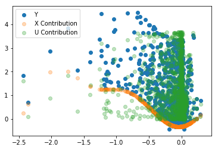

```python
Y_nonlin = torch.tensor(X_cont + 2*U_cont)
plt.scatter(X, Y_nonlin, label='Y')
plt.scatter(X, X_cont, label='X Contribution', alpha=0.3)
plt.scatter(X, 2*U_cont, label='U Contribution', alpha=0.3)
plt.legend()
```

The treatment model hasn't changed, but we do need a more flexible second-stage estimator:

```python
class FlexNet(torch.nn.Module):
    def __init__(self, dim):
        # define network params
        super(FlexNet, self).__init__()
        self.dim = dim
        self.h1_size = 5
        self.h2_size = 5
        self.out = 1
        self.lin1 = torch.nn.Linear(self.dim, self.h1_size)
        self.lin2 = torch.nn.Linear(self.h1_size, self.h2_size)
        self.out_layer = torch.nn.Linear(self.h2_size, self.out)

    def forward(self, x):
        h1 = torch.nn.functional.relu(self.lin1(x.reshape(-1, self.dim)))
        h2 = torch.nn.functional.relu(self.lin2(h1))
        return self.out_layer(h2).flatten()
```

Let's check that the neural net is sufficiently flexible to recover $X$'s true contribution to $Y$, by regressing `X_cont` on $X$.

[figure not shown]

```python
plt.scatter(X_train, X_cont, label='True X contribution to Y')
X_pred = torch.linspace(X_train.min(), X_train.max())
plt.scatter(X_pred, net(X_pred).detach(), alpha=0.5, label='Predicted contribution')
plt.legend()
```

Learning the instrumental variable second stage estimator should recover X's true contribution, so again we build a model:

```python
def prob_net_nonlinear(dim, name):
    net = FlexNet(dim)
    h1, h2, out = net.h1_size, net.h2_size, net.out
    loc, scale = torch.zeros(1, 1), torch.ones(1, 1)
    # define priors
    w1_prior = dist.Normal(torch.zeros(h1, dim), torch.ones(dim))
    w2_prior = dist.Normal(torch.zeros(h2, h1), torch.ones(h1))
    w3_prior = dist.Normal(torch.zeros(out, h2), torch.ones(h2))
    b1_prior = dist.Normal(torch.zeros(h1), torch.ones(h1))
    b2_prior = dist.Normal(torch.zeros(h2), torch.ones(h2))
    b3_prior = dist.Normal(torch.zeros(out), torch.ones(out))
    priors = {'lin1.weight': w1_prior,
              'lin2.weight': w2_prior,
              'out_layer.weight': w3_prior,
              'lin1.bias': b1_prior,
              'lin2.bias': b2_prior,
              'out_layer.bias': b3_prior,}
    lifted_net = pyro.random_module(name, net, priors)
    return lifted_net()
```

```python
def model(tm, Z, Y, n_samples):
    g = prob_net_nonlinear(1, 'g')
    mu, cov = tm.predict(Z)
    samples = dist.MultivariateNormal(mu, torch.diag(cov))
    with pyro.plate("X_samples", n_samples):
        X_hat = pyro.sample('X_hat', samples).reshape(-1, 1)
    y_mu = g(X_hat).squeeze(-1)
    if Y is not None:
        Y = Y.repeat(n_samples)
    y_pred = pyro.sample("y_pred",
                         dist.Normal(y_mu, 0.1),
                         obs=Y)
    return y_pred

blocked_model = poutine.block(model, hide=['X_hat', 'X_samples'])
```

And then we use variational inference to train again:

```python
pyro.clear_param_store()
guide = pyro.contrib.autoguide.AutoDiagonalNormal(blocked_model)
loss = pyro.infer.TraceMeanField_ELBO()
# optim = pyro.optim.SGD({'lr':1e-3, 'momentum':1e-2})
optim = pyro.optim.Adam({'lr':1e-1})
# optim = pyro.optim.ClippedAdam({'lr': 1e-3})
svi = pyro.infer.SVI(blocked_model, guide, optim, loss)
losses = []
n_steps = 60000
n_samples = 10
diff = 4
n_iters = 0
# while diff > 0.4 and n_iters < n_steps:
for s in range(n_steps):
    if float(diff) < 0.25:
        break
    n_iters += 1
    l = svi.step(tm, Z.squeeze(-1), Y_nonlin, n_samples)
    losses.append(l)
    if s % 100 == 0:
        qs = guide.quantiles([0.05, 0.5, 0.95])['g$$$lin1.weight']
        q05, q5, q95 = qs[0][0].detach(), qs[1][0].detach(), qs[2][0].detach()
        qs = [i for i in map(lambda x: round(float(x), 2), [q05, q5, q95])]
        diff = abs(q95 - q05)
        print("\nLoss ({}):".format(s), l)
        print("Quantiles: {}".format(qs))
        print("Diff: {}".format(diff))
```

```
Loss (0): 4380778.5
Quantiles: [-1.72, 0.1, 1.92]
Diff: tensor([3.6357])

Loss (100): 851332.0625
Quantiles: [0.16, 1.07, 1.98]
Diff: tensor([1.8264])

Loss (200): 696501.75
Quantiles: [0.15, 1.07, 1.99]
Diff: tensor([1.8318])

Loss (300): 689605.0
Quantiles: [0.15, 1.07, 1.98]
Diff: tensor([1.8320])

Loss (400): 674140.5
Quantiles: [0.16, 1.07, 1.99]
Diff: tensor([1.8301])

Loss (500): 671599.5625
Quantiles: [0.15, 1.07, 1.98]
Diff: tensor([1.8303])

Loss (600): 670607.8125
Quantiles: [0.14, 1.07, 1.99]
Diff: tensor([1.8482])

Loss (700): 674892.625
Quantiles: [0.12, 1.05, 1.98]
Diff: tensor([1.8622])

Loss (800): 667784.0625
Quantiles: [0.11, 1.04, 1.98]
Diff: tensor([1.8626])

Loss (900): 672386.8125
Quantiles: [0.11, 1.04, 1.98]
Diff: tensor([1.8628])

```

[output cut: 2344 more lines]

```
Loss (59600): 668202.1875
Quantiles: [-1.45, 0.09, 1.62]
Diff: tensor([3.0736])

Loss (59700): 668143.8125
Quantiles: [-1.45, 0.1, 1.64]
Diff: tensor([3.0884])

Loss (59800): 668194.375
Quantiles: [-1.51, 0.09, 1.69]
Diff: tensor([3.2005])

Loss (59900): 668151.25
Quantiles: [-1.55, 0.09, 1.73]
Diff: tensor([3.2771])
```

### Check its predictive performance

```python
get_marginal = lambda traces, sites: pyro.infer.EmpiricalMarginal(traces, sites)._get_samples_and_weights()[0].detach().cpu().numpy()

def wrapped_model(tm, Z, Y, n_samples):
    pyro.sample("prediction", dist.Delta(model(tm, Z, Y, n_samples)))

posterior = svi.run(tm, Z.squeeze(-1), None, 1)

trace_pred = pyro.infer.TracePredictive(wrapped_model,
                                        posterior,
                                        num_samples=100)

post_pred = trace_pred.run(tm, Z.squeeze(-1), None, 1)
y_pred_samples = get_marginal(post_pred, sites=['y_pred'])
y_pred = y_pred_samples.mean(axis=0).flatten()

# post_summary = summary(post_pred, sites= ['y_pred'])
# mu = post_summary["y_pred"]
```

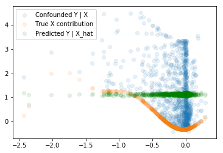

```python
plt.scatter(X, Y_nonlin, alpha=0.1, label='Confounded Y | X')
plt.scatter(X, X_cont, alpha=0.1, label='True X contribution')
plt.scatter(X, y_pred, alpha=0.1, color='green', label='Predicted Y | X_hat')
plt.legend()
```

...training NN's is annoying.

# What can we do with this?

1. **Better treatment effect models:** Nonlinear, probabilistic treatment effect models
   1. May provide automatic *heterogeneous treatment effect* estimation
2. **Deconfound with no instruments:** 2nd-stage estimation may provide deconfounded prior in cases when you have no instrumental variable
3. **Deconfound by learning hidden structure:** Or, you can estimate the influence of the unobserved variable (with VI, for example) and use that to deconfound treatment effect estimation